# HW2 Po-Chun Chen N11957611

## Q1

Assume the systolic blood pressure in a population of healthy individuals is described by a normal distribution with a mean of 121.7 mmHg and a standard deviation of 13.2.  
If we want to design a test for high blood pressure so there is only a 5% chance of having a false positive when tested against a patient without hypertension, what cutoff should we use?

|  | Positive | Negative |  |
| --- | --- | --- | --- |
| Positive |  | False Positive(Type I error) |  |
| Negative | False Negative(Type II error) |  |  |

A: We should use 143.41 as our cutoff A false positive is an error in data reporting in which a test result improperly indicates presence of a condition, such as a disease (the result is positive), when in reality it is not present.

#### Distribution of the blood pressure

```r
x<-rnorm(10000,mean=121.7,sd=13.2)
dnorm(x,mean=121.7,sd=13.2)
```

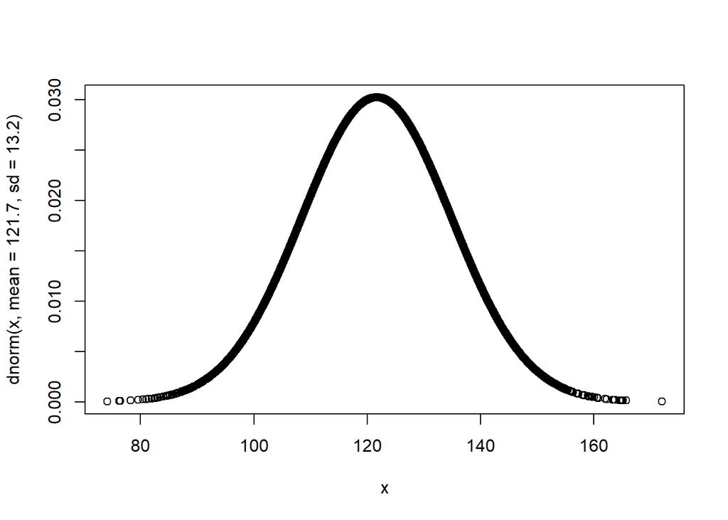

```r
plot(x,dnorm(x,mean=121.7,sd=13.2))
```

#### Area in the skyblue color portion is 95%

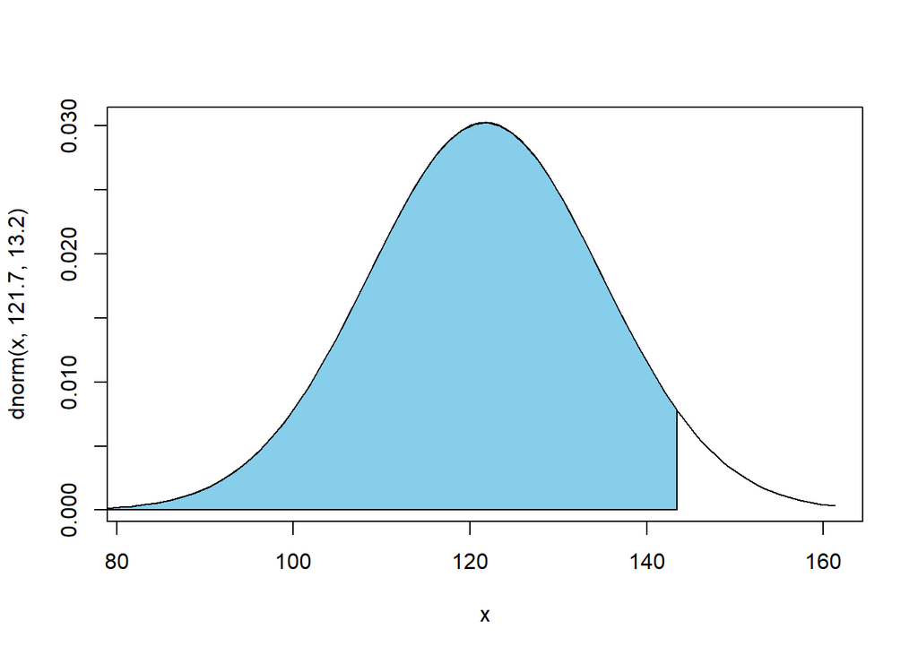

```r
lower.x <- 0
upper.x <- 143.4121
step <- (upper.x - lower.x) / 100
sigma <- 13.2
mu <- 121.7
bounds <- c(mu-3*sigma, mu+3*sigma)
cord.x <- c(lower.x,seq(lower.x,upper.x,step),upper.x)
cord.y <- c(0,dnorm(seq(lower.x,upper.x,step),mu,sigma),0)
curve(dnorm(x,121.7,13.2),xlim=bounds)
polygon(cord.x,cord.y,col='skyblue')
```

Therefore, we should set the cut off as 143.41 by qnorm

```r
qnorm(0.950, mean = 121.7, sd = 13.2)
```

```
## [1] 143.4121
```

```r
pnorm(143.4121,mean = 121.7, sd = 13.2)
```

```
## [1] 0.9500003
```

## Q2

Gene expression data will be used in many examples in this course.

Gene expression data is typically log-normally distributed. Assume we are studying a gene with a lognormal distribution of expression with a (log) mean of 12.3 and (log) standard deviation of 2.5 (arbitrary) units. Simulate taking a sample of size 1000 from this log normal distribution and plot the density.

#### plot the density

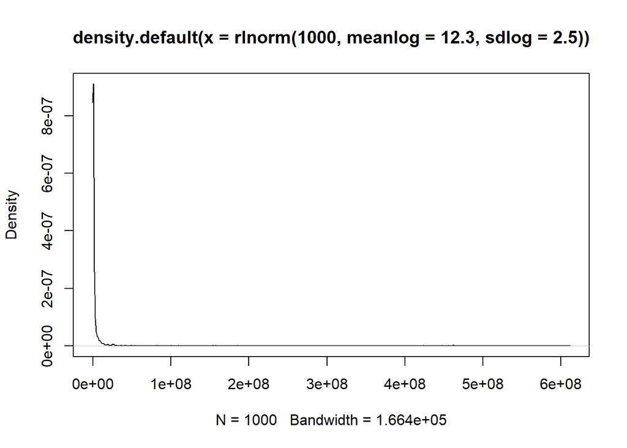

```r
plot(density(rlnorm(1000, meanlog = 12.3, sdlog = 2.5)))
```

#### Plot the density of this data again after transforming it by the log() function.

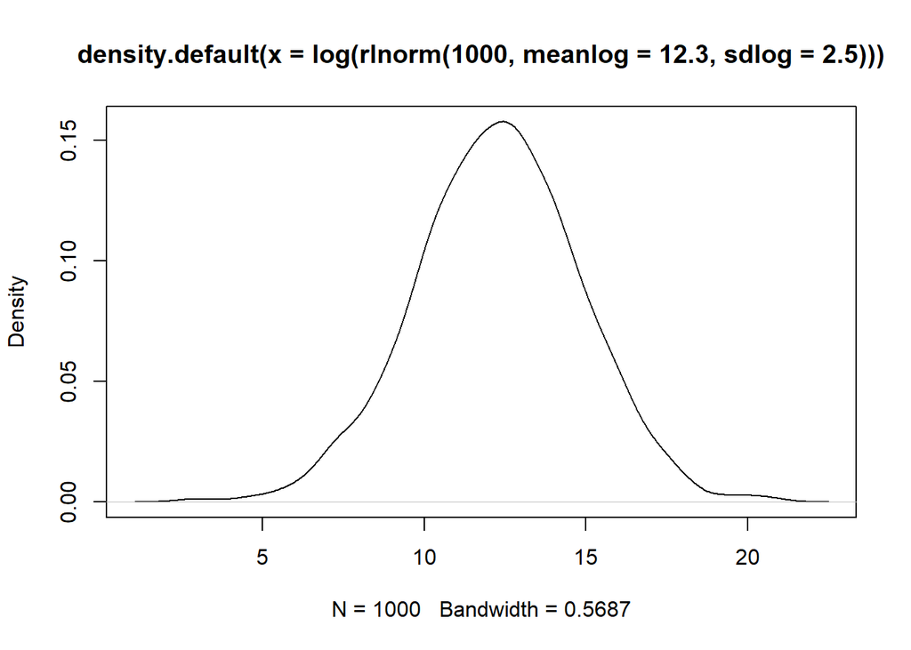

```r
plot(density(log(rlnorm(1000, meanlog = 12.3, sdlog = 2.5))))
```

#### Comment on the shape of the distribution after log transformation.

A: The shape after log transformation is like a normal distribution graph

#### What is the probability a gene expression of 22.3 units or less would be measured from this distribution?

```r
plnorm(22.3,meanlog = 12.3, sdlog = 2.5)
```

```
## [1] 0.0001174588
```

Hint: look at the lognormal distribution in Aho (3.3.2.8) and at rlnorm in the R help and in particular pay attention to what arguments are required.

## Q3

In this exercise, we’ll use for() and while() loops to understand the effects of different parameters in Bayes’ theorem.

Create a vector that contains all the values that are multiples of 0.01, from (and including) 0.01 up to (and including) 1. You may use the seq() function. Name this vector “prior”. These values will represent different prior probabilities (e.g. prevalence of a disease prior to screening).

```r
prior<-c(1:100)
for(a in 0:100){
  prior[a]<- (a)/100
}
prior
```

```
##   [1] 0.01 0.02 0.03 0.04 0.05 0.06 0.07 0.08 0.09 0.10 0.11 0.12 0.13 0.14
##  [15] 0.15 0.16 0.17 0.18 0.19 0.20 0.21 0.22 0.23 0.24 0.25 0.26 0.27 0.28
##  [29] 0.29 0.30 0.31 0.32 0.33 0.34 0.35 0.36 0.37 0.38 0.39 0.40 0.41 0.42
##  [43] 0.43 0.44 0.45 0.46 0.47 0.48 0.49 0.50 0.51 0.52 0.53 0.54 0.55 0.56
##  [57] 0.57 0.58 0.59 0.60 0.61 0.62 0.63 0.64 0.65 0.66 0.67 0.68 0.69 0.70
##  [71] 0.71 0.72 0.73 0.74 0.75 0.76 0.77 0.78 0.79 0.80 0.81 0.82 0.83 0.84
##  [85] 0.85 0.86 0.87 0.88 0.89 0.90 0.91 0.92 0.93 0.94 0.95 0.96 0.97 0.98
##  [99] 0.99 1.00
```

```r
prior<-c(1:100)
a<-1
while (a<=100) {
  prior[a]<- (a)/100
  a<-a+1
}
prior
```

```
##   [1] 0.01 0.02 0.03 0.04 0.05 0.06 0.07 0.08 0.09 0.10 0.11 0.12 0.13 0.14
##  [15] 0.15 0.16 0.17 0.18 0.19 0.20 0.21 0.22 0.23 0.24 0.25 0.26 0.27 0.28
##  [29] 0.29 0.30 0.31 0.32 0.33 0.34 0.35 0.36 0.37 0.38 0.39 0.40 0.41 0.42
##  [43] 0.43 0.44 0.45 0.46 0.47 0.48 0.49 0.50 0.51 0.52 0.53 0.54 0.55 0.56
##  [57] 0.57 0.58 0.59 0.60 0.61 0.62 0.63 0.64 0.65 0.66 0.67 0.68 0.69 0.70
##  [71] 0.71 0.72 0.73 0.74 0.75 0.76 0.77 0.78 0.79 0.80 0.81 0.82 0.83 0.84
##  [85] 0.85 0.86 0.87 0.88 0.89 0.90 0.91 0.92 0.93 0.94 0.95 0.96 0.97 0.98
##  [99] 0.99 1.00
```

Now, let’s revise the breast cancer example from last week:

Assuming that: Given the prior probability (for the values specified above) of women at age forty who participate in routine screening having breast cancer; 80% of women with breast cancer will get positive mammographies; and 9.6% of women without breast cancer will also get positive mammographies. A woman in this age group has a positive mammography in a routine screening. What is the probability that she actually has breast cancer? Create a for() loop that inserts each value from “prior” into Bayes’ theorem, and calculates the posterior probability (i.e. Pr{Disease is present | Positive Test Result} ). Leave all other values constant according to the example. Save each value/answer into a vector called “posteriorFor”.

```r
posteriorFor<-c(1:100)
prior<-seq(0.01,1,0.01)
for(a in 0:100){
  posteriorFor[a] <- prior[a]*0.8/(prior[a]*0.8+(1-prior[a])*0.096)
}
posteriorFor
```

```
##   [1] 0.07763975 0.14534884 0.20491803 0.25773196 0.30487805 0.34722222
##   [7] 0.38546256 0.42016807 0.45180723 0.48076923 0.50738007 0.53191489
##  [13] 0.55460751 0.57565789 0.59523810 0.61349693 0.63056380 0.64655172
##  [19] 0.66155989 0.67567568 0.68897638 0.70153061 0.71339950 0.72463768
##  [25] 0.73529412 0.74541284 0.75503356 0.76419214 0.77292111 0.78125000
##  [31] 0.78920570 0.79681275 0.80409357 0.81106870 0.81775701 0.82417582
##  [37] 0.83034111 0.83626761 0.84196891 0.84745763 0.85274542 0.85784314
##  [43] 0.86276083 0.86750789 0.87209302 0.87652439 0.88080960 0.88495575
##  [49] 0.88896952 0.89285714 0.89662447 0.90027701 0.90381992 0.90725806
##  [55] 0.91059603 0.91383812 0.91698842 0.92005076 0.92302879 0.92592593
##  [61] 0.92874543 0.93149038 0.93416370 0.93676815 0.93930636 0.94178082
##  [67] 0.94419391 0.94654788 0.94884488 0.95108696 0.95327605 0.95541401
##  [73] 0.95750262 0.95954357 0.96153846 0.96348884 0.96539619 0.96726190
##  [79] 0.96908734 0.97087379 0.97262248 0.97433460 0.97601129 0.97765363
##  [85] 0.97926267 0.98083942 0.98238482 0.98389982 0.98538530 0.98684211
##  [91] 0.98827107 0.98967298 0.99104859 0.99239865 0.99372385 0.99502488
##  [97] 0.99630238 0.99755700 0.99878935 1.00000000
```

#### Plot a line graph with “prior” on the x-axis, and “posteriorFor” on the y-axis. Make sure that both x- and y- axes run from 0 to 1.

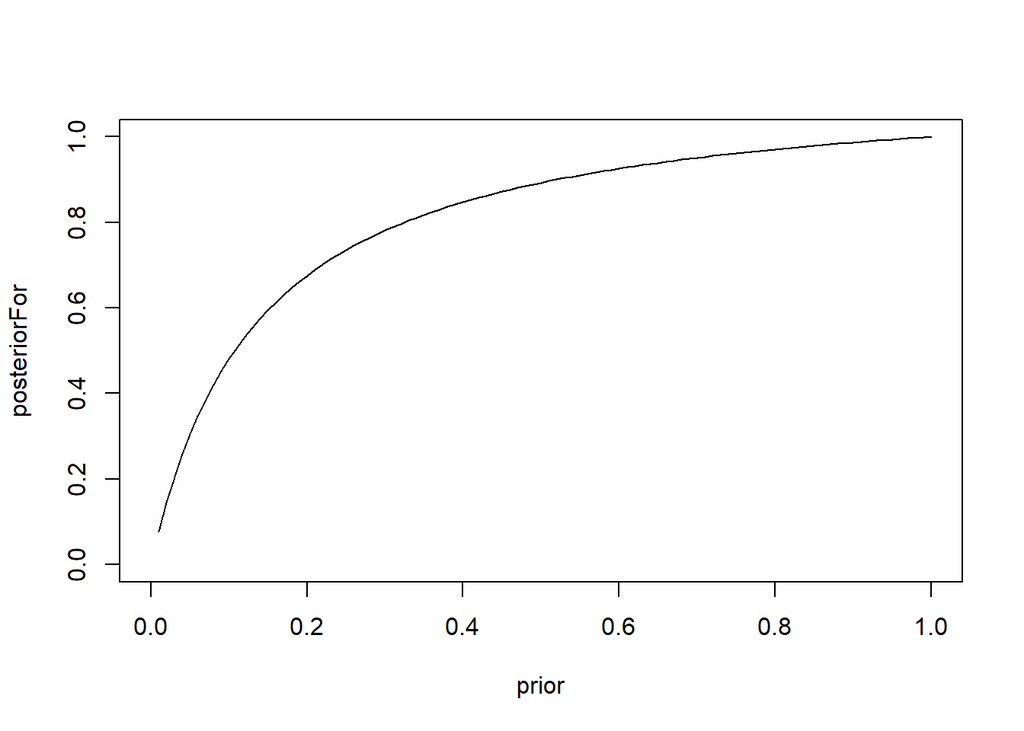

```r
plot(prior,posteriorFor,xlim = c(0,1),ylim = c(0,1),type="l")
```

## Chapter 4

### 4.4

Let X be a discrete random variable with the pdf f(x) = x/8 if x = 1, 2, or 5, and f(x) = 0; otherwise, find  
a. E(X)  
b. Var(X)  
c. E(2X + 3)

#### a

$$E(X) = (1/8)*1+(2/8)*2+(5/8)*5 = 30/8 = 3.75$$

#### b

$$\begin{equation}\begin{split} Var(X) &= E(X^2)-E(X)^2 \\&= ((1/8)*1+(2/8)*4+(5/8)*25)-3.75^2 \\&= 2.6875 \end{split}\end{equation}$$

#### c

$$E(2X+3) = 2E(X)+3 = 10.5$$

### 4.5

Let X be a continuous random variable with the pdf f(x) = 3x^2 if 0 < x < 1; using calculus, find  
a. E(X)  
b. Var(X)  
c. E(2X + 3)

#### a

$$\begin{equation}\begin{split}E(x)&=\int_0 ^1 x*3x^{2} dx \\ &= \int_0 ^1 3x^{3} dx \\ &= 3/4*[x^4]_{0}^{1}=3/4\end{split}\end{equation}$$

#### b

$$\begin{equation}\begin{split} Var(X) &= E(X^2)-E(X)^2 \\&= \int_0 ^1 x^2*3x^{2} dx-(3/4)^2 \\&= \int_0 ^1 3x^{4} dx -9/16 \\ &= 3/5*[x^5]_{0}^{1}-9/16 \\&=3/80\end{split}\end{equation}$$

#### c

$$E(2X+3) = 2E(X)+3 = 2*(3/4)+3=4.5$$

### 4.6

Using the equation for the exponential cdf, show that the median of the exponential distribution is −ln(0.5)/θ.

$$Solve:1-e^{-x\theta} = 1/2$$
$$\begin{equation}\begin{split} &=> -e^{-x\theta} = -1/2\\&=>e^{-x\theta}=1/2\\&=> -x\theta = ln(1/2)\\&=>x=-\frac{ln(1/2)}{\theta}\end{split}\end{equation}$$

### 4.15

Write R functions for $\bar{X}$ and $S^2$ without using the existing functions mean, sd, or var.

#### $\bar{X}$

```r
arithmeticmean.function <- function(x){
  number <-0
  temp <-0
  for (a in x) {
    temp <- a+temp
    number <- number+1
  }
  temp<- temp/number
  return (temp)
}
arithmeticmean.function(c(1:100))
```

```
## [1] 50.5
```

```r
arithmeticmean.function(c(7,8,8,8,9))
```

```
## [1] 8
```

#### $S^2$

```r
variance.function <- function(x){
  number <-0
  temp <-0
  temp2<-0
  for (a in x) {
    temp <- a+temp
    number <- number+1
  }
  temp<- temp/number
  for (a in x) {
    temp2 <- (a-temp)^2+temp2
  }
  temp2<- temp2/number
  return (temp2)
}
variance.function(c(8,10,11,15,20))
```

```
## [1] 18.16
```

```r
variance.function(c(7,8,8,8,9))
```

```
## [1] 0.4
```

### 4.29

Let X ~ N(2, 4) and let Y ~ N(3, 2). Define the distribution of  
a. 3X + 7  
b. Y/10  
c. 3(X – Y)

#### a

A: N(13,36)

N($\mu$,$\sigma^2(variacne)$) N(2,4) => $\mu$ = 2, $\sigma^2 = 4$

$$X \,become\, 3X+7\\ \mu => \,3*2+7=13 \\ \sigma^2 => 9*4 = 36$$
$$3X+7 \sim N(13,36)$$

#### b

A: N(3/10,2/100)

N(3,2) => $\mu$ = 3, $\sigma^2 = 2$

$$Y \,become\, \frac{Y}{10} \\ \mu => \,3/10 \\ \sigma^2 => 2/100$$
$$\frac{Y}{10} \sim N(0.3,0.02)$$

#### c

N(3,2) => $\mu$ = 3, $\sigma^2 = 2$

$$3(X-Y) \\= 3X-3Y \\ \mu=> \,3*(2)-3*(3)=-3 \\ \sigma^2 => 9*(4)+9*(2) = 54$$
$$3(X-Y) \sim N(-3,54)$$